# Tidy Text Notebook

By David Robinson and Julia Silge

Sean Nguyen

This is my notebook that I will used to go through the tidy text notebook by Julia Silge and David Robinson.

```r
library(tidyverse)
library(tidytext)
library(stringr)
library(janeaustenr)
text <- c("Because I could not stop for Death - ",
          "He kindly stopped for me -",
          "The Carriage held but just Ourselves -",
          "and Immortality")
text
```

```
[1] "Because I could not stop for Death - "  "He kindly stopped for me -"
[3] "The Carriage held but just Ourselves -" "and Immortality"
```

```r
text_df <- data_frame(line = 1:4, text = text)
text_df
```

| line | text |
| --- | --- |
| 1 | Because I could not stop for Death - |
| 2 | He kindly stopped for me - |
| 3 | The Carriage held but just Ourselves - |
| 4 | and Immortality |

```r
text_df %>%
  unnest_tokens(word, text)  # to_lower = FALSE to keep uppercase
```

| line | word |
| --- | --- |
| 1 | because |
| 1 | i |
| 1 | could |
| 1 | not |
| 1 | stop |
| 1 | for |
| 1 | death |
| 2 | he |
| 2 | kindly |
| 2 | stopped |

[output cut: 10 more lines]

### Working with Jane Austen Books

Using the Jane Austen dataset we can make it tidy. First we’ll use mutate to create a column from existing data. Annotate line numbers and then keep track of chapters using regex.

```r
original_books <- austen_books() %>%
  group_by(book) %>%
  mutate(linenumber = row_number(),
         chapter = cumsum(str_detect(text, regex("^chapter [\\divxlc]",
                                                  ignore.case = TRUE)))) %>%
  ungroup()
original_books
```

| text | book | linenumber | chapter |
| --- | --- | --- | --- |
| SENSE AND SENSIBILITY | Sense & Sensibility | 1 | 0 |
|  | Sense & Sensibility | 2 | 0 |
| by Jane Austen | Sense & Sensibility | 3 | 0 |
|  | Sense & Sensibility | 4 | 0 |
| (1811) | Sense & Sensibility | 5 | 0 |
|  | Sense & Sensibility | 6 | 0 |
|  | Sense & Sensibility | 7 | 0 |
|  | Sense & Sensibility | 8 | 0 |
|  | Sense & Sensibility | 9 | 0 |
| CHAPTER 1 | Sense & Sensibility | 10 | 0 |

[output cut: 990 more lines]

Restructure it in *one-token-per-row* format with the **unnest_tokens()** function.

```r
tidy_books <- original_books %>%
  unnest_tokens(word, text)
tidy_books
```

| book | linenumber | chapter | word |
| --- | --- | --- | --- |
| Sense & Sensibility | 1 | 0 | sense |
| Sense & Sensibility | 1 | 0 | and |
| Sense & Sensibility | 1 | 0 | sensibility |
| Sense & Sensibility | 3 | 0 | by |
| Sense & Sensibility | 3 | 0 | jane |
| Sense & Sensibility | 3 | 0 | austen |
| Sense & Sensibility | 5 | 0 | 1811 |
| Sense & Sensibility | 10 | 0 | chapter |
| Sense & Sensibility | 10 | 0 | 1 |
| Sense & Sensibility | 13 | 0 | the |

[output cut: 990 more lines]

#### Removing stop words

We can remove *stop words*

```r
data(stop_words)
tidy_books <- tidy_books %>%
  anti_join(stop_words)
tidy_books %>%
  count(word, sort = TRUE)
```

| word | n |
| --- | --- |
| miss | 1855 |
| time | 1337 |
| fanny | 862 |
| dear | 822 |
| lady | 817 |
| sir | 806 |
| day | 797 |
| emma | 787 |
| sister | 727 |
| house | 699 |

[output cut: 990 more lines]

Plotting data

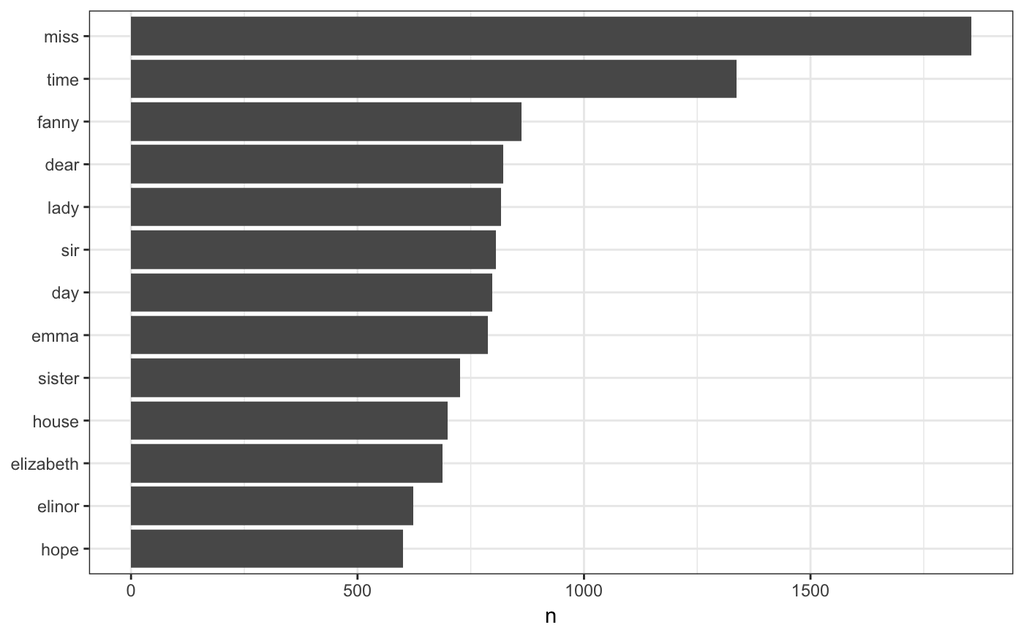

```r
tidy_books %>%
  count(word, sort = TRUE) %>%
  filter(n > 600) %>%
  mutate(word = reorder(word, n)) %>%
  ggplot(aes(word, n))+
  geom_col()+
  xlab(NULL)+
  coord_flip()+
  theme_bw()
```